# 23.1. Package Information

As remarked earlier, a good way to look at the source packages on CRAN. Lectures 10 and 14 covered many details.

Then you can also look at what happens on your machine when you actually install the package.

# 23.1.1. Structure of R package

Here is a table that shows the various directories in a typical R source package. *Auto* indicates that some tools will generate this automatically for you.

| file | description |
| --- | --- |
| DESCRIPTION | Basic info about the package |
| NAMESPACE | Contains namespace directives describing the imports and exports. Auto |
| data/ | Contains datasets saved in RData format (extension .rda) |
| man/ | Help pages in rdoc format. Auto. |
| R/ | R code, written by user along with roxygen tags for documentation |
| src/ | C/C++, Fortran or other code |
| vignettes/ | Vignettes for package in Rmd format (or Sweave) |
| demo/ | Demo R scripts to show off the package. |
| tests/ | Unit and other tests |
| exec/ | Scripts that may be used by package, possibly in other languages |
| inst/ | Other installed files or folders |

# 23.1.1. What lands where

Let us examine the `Rcpp` package.

Download the `Rcpp` source package. Examine where the various files land when the package is *installed* on your machine.

Do this for `dplyr` on your own, to really understand what is going on.

*NOTE* Do not forget that if you need to access auxilliary files or data that you bundled in your package, `system.file` provides a hassle-free way of getting at them.

# 23.1.2. Dependencies

[output not shown]

# 23.1.3. Import and Suggest

```r
@importFrom foo bar
```

rather than

```r
@import foo
```

The latter imports everything in the package `foo`, whereas the former is specific. Specificity is good!

Importing a function, by hand, from another package requires the updating of at least two files: `DESCRIPTION` and `NAMESPACE`, always creating a possibility for mistakes. The function `devtools::use_package` does this automatically for you.

So when to import everything from a package?

When you think you will be using pretty much everything! This should not be a flippant call, because there are consequences downstream and for the future.

For example, S4 classes will need to pretty much import the entire `methods` package. Otherwise, some wierd error messages might result.

More often, you will use `importFrom` to pick up specific things you need from various packages.

# 23.1.4. Disambiguation

Suppose we have a function `h` for our package as follows.

```r
#' The h function
#' Plot \code{Sepal.Width} versus \code{Sepal.Length} for the \link[datasets]{iris} dataset
#' @keywords graphics
#' @importFrom ggplot2 qplot
#' @export
#' @examples
#' h()
#'
h <- function() {
    qplot(Sepal.Length, Sepal.Width, data = iris)
}
```

Although the above looks fine and works alright, it could be improved.

One thing is that later as you update your function `h` in future versions of the package, you may also import another function `qplot` from another package `quirky`, say. In that case, you want to control which `qplot` your function uses.

So the recommended coding practice these days is to be *unambiguous* by using the fully qualified function name: `foo::f` for function `f` from package `foo`.

```r
#' The h function
#' Plot \code{Sepal.Width} versus \code{Sepal.Length} for the \link[datasets]{iris} dataset
#' @keywords graphics
#' @importFrom ggplot2 qplot ggplot
#' @export
#' @examples
#' h()
#'
h <- function() {
    ggplot2::qplot(Sepal.Length, Sepal.Width, data = iris)
}
```

To summarize: *import specifically and use unambiguously*. That is why the `devtools::use_package` recommends you to do that.

Many who convert R scripts into packages forget to do this, making their packages less robust: depending on what the user does, the results could be very different!

Next, recall that `library("foo")` or `require("foo")` both load package `foo` and attach it, i.e. it place the package in the search path. *These will never to be used in a package, with `shiny` apps being the only exception!*

But you can also plainly load a package: that is load the code, data, plus dynamically compiled code *without* placing it on the search path using `loadNamespace` or `requireNamespace`.

The latter may be used with a suggested package for example.

```r
library("ggplot2")
search()
```

```
##  [1] ".GlobalEnv"        "package:ggplot2"   "ESSR"
##  [4] "package:stats"     "package:graphics"  "package:grDevices"
##  [7] "package:datasets"  "package:rmarkdown" "package:knitr"
## [10] "package:pkgdown"   "package:devtools"  "package:usethis"
## [13] "package:utils"     "package:methods"   "Autoloads"
## [16] "package:base"
```

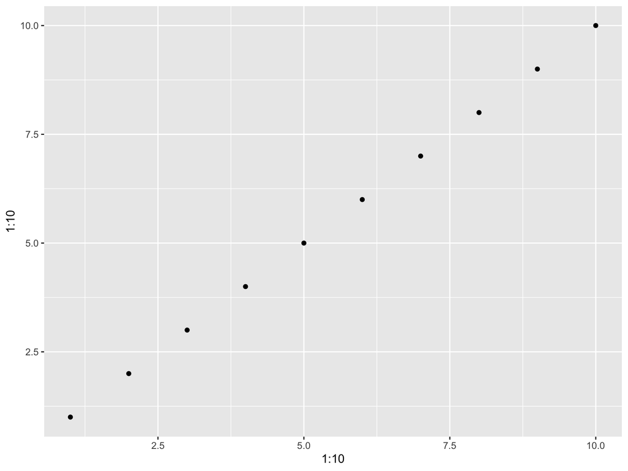

```r
qplot(1:10, 1:10)
```

```r
detach("package:ggplot2")
search()
```

```
##  [1] ".GlobalEnv"        "ESSR"              "package:stats"
##  [4] "package:graphics"  "package:grDevices" "package:datasets"
##  [7] "package:rmarkdown" "package:knitr"     "package:pkgdown"
## [10] "package:devtools"  "package:usethis"   "package:utils"
## [13] "package:methods"   "Autoloads"         "package:base"
```

```r
qplot(1:10, 1:10)
```

```
## Error in qplot(1:10, 1:10): could not find function "qplot"
```

The function `detach` merely removes it from the search path. However, the package namespace is still loaded. It is the namespace object that contains all the relevant code and objects you want to use.

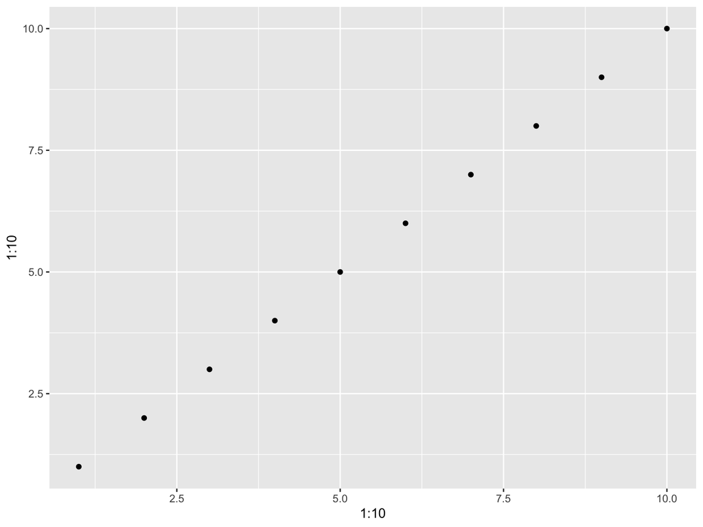

```r
ggplot2::qplot(1:10, 1:10)
```

will work because of the explicit reference.

# 23.1.5. Suggests

The above idea of loaded name spaces can be exploited when your package *suggests* other packages. For example, if you want to show off your package that allows for 3d plots, you want to use the package `rgl`. Not everyone may have it, and sometimes such packages may not be available on all platforms. But where available, you’d like to show some cool interactive 3d stuff!

```r
if (requireNamespace("rgl", quietly = TRUE)) {
    rgl::plot3d(...)
} else {
    ## do something else not involving rgl.
}
```

The above is a fail-safe method for loading `rgl` if it exists, othewise doing vanilla stuff.

As an example, consider the `cubature` package, source available on [Github](https://bnaras.github.io/cubature/). We will examine the use of suggested packages.

The cubature vignette shows the effects of vectorization and how it can be exploited for great gains in speed. Points to note are:

- For timing it uses a package called `benchr`
- It compares how fast the routines are compared to another specialized packages `mvtnorm`.
- A user would be able to use this package perfectly without the other packages. Therefore, it does not make sense to import the other packages nor require the user install them.

Therefore, they belong in the *Suggests* category!

# 23.1.6. How exactly do `NAMESPACE`s work?

From the R-exts manual:

> Namespaces are sealed once they are loaded. Sealing means that imports and exports cannot be changed and that internal variable bindings cannot be changed. Sealing allows a simpler implementation strategy for the namespace mechanism. Sealing also allows code analysis and compilation tools to accurately identify the definition corresponding to a global variable reference in a function body. … The namespace controls the search strategy for variables used by functions in the package. If not found locally, R searches the package namespace first, then the imports, then the base namespace and then the normal search path.

__

For example, the `nrow` function is defined as follows:

```r
nrow
```

```
## function (x)
## dim(x)[1L]
## <bytecode: 0x7fc7aa7a2490>
## <environment: namespace:base>
```

Suppose in an R session, we change the `dim` function:

```r
dim <- function(x) "Got you"
```

```r
nrow(data.frame(x = letters[1:5], y = 1:5))
```

```
## [1] 5
```

we still get a sane answer. Why? Because `nrow` is in the `base` package and it knows to look for it in that package. In other words, when the package was built and installed, the reference to `dim` in `nrow` was made to the appropriate function and *sealed*. (Well, sorta, but there are functions to manipulate namespaces too.)